# 11-监督学习：回归

##### 5. 模型结果初步解读

summary()函数包含了每一个预测因子（自变量）的结果，就像一元线性回归案例中的一元预测因子一样的形式：

```r
summary(lm2)
```

```
##
## Call:
## lm(formula = prestige ~ ., data = trainPrestige)
##
## Residuals:
##      Min       1Q   Median       3Q      Max
## -13.1018  -4.6074   0.7782   4.0556  19.8466
##
## Coefficients:
##               Estimate Std. Error t value Pr(>|t|)
## (Intercept) -1.455e+01  1.253e+01  -1.161  0.25109
## education    4.477e+00  7.912e-01   5.658 6.63e-07 ***
## income       8.964e-04  3.139e-04   2.856  0.00616 **
## women       -4.092e-03  3.852e-02  -0.106  0.91581
## census       1.129e-03  1.175e-03   0.961  0.34102
## typeprof     6.654e+00  7.572e+00   0.879  0.38357
## typewc      -2.955e+00  5.208e+00  -0.567  0.57297
## ---
## Signif. codes:  0 '***' 0.001 '**' 0.01 '*' 0.05 '.' 0.1 ' ' 1
##
## Residual standard error: 7.02 on 52 degrees of freedom
## Multiple R-squared:  0.855,  Adjusted R-squared:  0.8382
## F-statistic: 51.08 on 6 and 52 DF,  p-value: < 2.2e-16
```

注意：在R中使用`lm()`函数拟合线性回归模型后，输出的摘要结果（使用`summary(lm)`查看）通常会显示每个变量的系数估计值、标准误差、t值以及p值。根据p值的大小，系统会自动为估计（回归）系数旁边添加星号标记：

- 没有星号：p值 > 0.05，表示不显著
- `*`：p值 ≤ 0.05，表示在5%水平上显著
- `**`：p值 ≤ 0.01，表示在1%水平上显著
- `***`：p值 ≤ 0.001，表示在0.1%水平上非常显著

系数旁没有星号标记的变量（即p值大于0.05的变量）可以被认为是不显著的，可以考虑从模型中删除这些变量，因为它们对预测结果没有统计上显著的贡献：

- 这是基于统计假设检验中的置信度概念。p值代表了在原假设（该变量系数为零）为真的条件下，观察到当前或更极端结果的概率——较小的p值表明有足够证据拒绝原假设，认为该变量在模型中具有统计学意义。
- 在实际应用中，是否真的删除不显著的变量还需要考虑领域知识和模型的整体表现；有时出于理论原因，即使变量不显著也可能被保留在模型中。

#### (2)模型诊断：对训练集模型进行模型诊断

一旦得到一个拟合后的线性模型，你应该运行一些诊断图来完全理解结果：

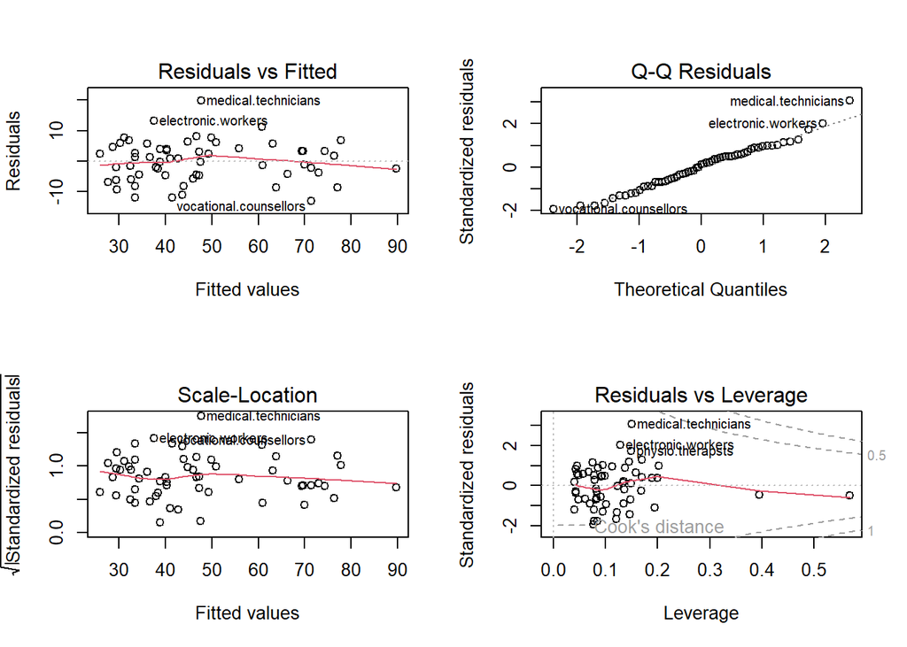

```r
par(mfrow=c(2,2))
plot(lm2)
```

其实我觉得没必要自己绘制简单的这些分析图，因为plot函数直接输出的结果里面就包含这些图，而且plot函数附带的信息更加全面，更加便于我们进行模型诊断。

除非你希望基于下面的这些简单命令，配合绘图函数创造可以输出展示的解释性图表，才有必要自己去手搓。

##### 1. 拟合（预测）值-残差图（Residuals vs Fitted）——方差齐性和线性假设

我们可以手动绘制**拟合值（模型在训练集中的预测值）-残差（拟合模型后和实际值产生的差异）图**，用来确认**在0残差线（y轴上等于0的线）附近的分布情况**。

下图展示了一个“云”分布，证实了这个模型是正确的：

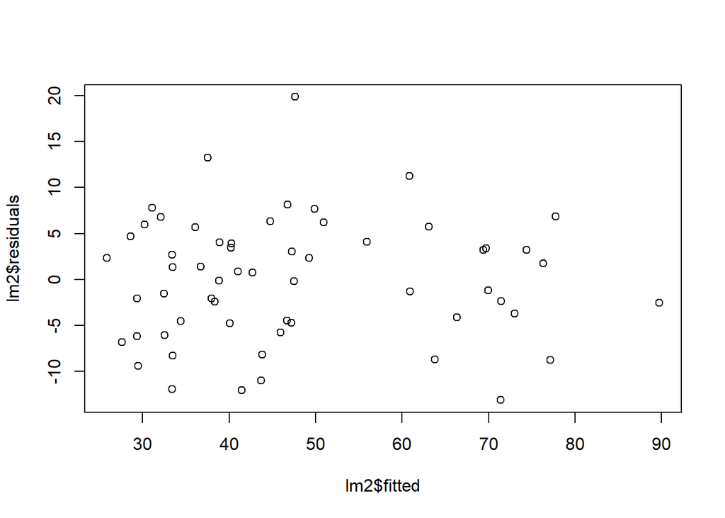

```r
plot(lm2$fitted, lm2$residuals)
```

1. 残差在0线（相当于模型拟合出的回归线）附近随机分布，说明拟合值-残差图中几乎没有模式，进而表明模型中没有非线性的成分：
   - 当线性模型正确捕捉了数据中所有的结构时，剩下的残差应该只包含随机误差。如果模型中缺少某种非线性关系，残差会保留这种结构化模式。
   - 当您看到残差随机散布在0线两侧，没有明显的模式（如曲线、U形或其他系统性趋势）时，这意味着您的线性模型已经捕捉了数据中的所有系统性变化；如果存在未被模型捕捉到的非线性关系，残差会显示出某种模式，表明线性模型漏掉了一些重要信息。
2. 残差形成一个大致水平的带状分布，表明误差方差相等（证明了方差齐性）：
   - 线性回归的一个重要假设是同方差性（homoscedasticity），即不同预测值水平的误差方差应该大致相同。
   - 当残差图显示一个均匀宽度的水平带状分布时，这表明无论预测值大小如何，误差的变异性都大致相同。如果带状分布呈现出”漏斗形”（如在一端宽在另一端窄），就表明存在异方差性（heteroscedasticity）——即误差方差随预测值变化，这违反了线性回归的基本假设。
   - 方差齐性对于确保参数估计的可靠性和统计推断的有效性非常重要，因为线性回归的标准错误计算假设误差项具有恒定方差。
3. 没有明显”突出”的残差，表明无异常值存在——如果你发现这个图中有一群明显的异常值，你可能需要探索一个或多个预测因子，才能解释这些异常值：
   - 异常值是与大多数数据点显著不同的观测值，**在多数语境中，异常值特指残差特别大的数据点**，在拟合值-残差图中表现为远离主要数据”云”的点。
   - 当拟合值-残差图没有明显的”突出”点时，这表明没有观测值产生特别大的误差。异常值在残差图中会显示为垂直方向上与大多数点明显分离的点。这些异常值可能代表：
     - 数据收集或记录错误
     - 特殊的案例或事件影响了这些观测值
     - 模型未能捕捉影响这些特定案例的重要因素
   - 如果存在异常值，它们可能对模型拟合产生不成比例的影响，使模型偏向于这些少数点，而不是代表大多数数据的一般模式。

##### 2. 残差值-索引图（有点类似于Cookie’s距离图的概念）——寻找异常点

前面我们提到，Cook’s距离是一个综合指标，它反映的是高影响点（高杠杆点(对模型拟合影响大的点)+异常点(残差的数值点)）在数据中的位置索引`Index`，即数据点对应在训练集或者说测试集的第几行。

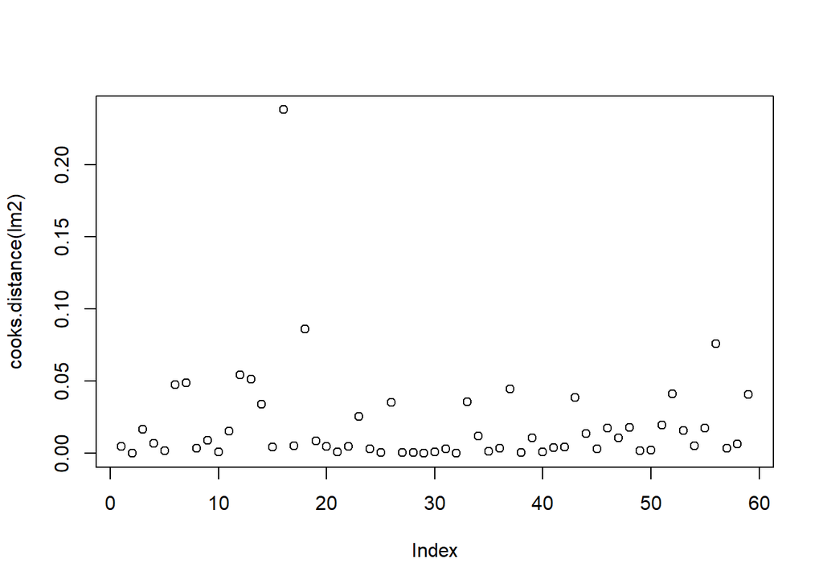

```r
par(mfrow=c(1,1))
plot(cooks.distance(lm2))
```

和Cooki’s距离相似的，诊断训练集的另一种常用技术是残差-索引图——索引指的是数据的行号，表明数据创建的特定顺序。和Cooki’s距离图不一样的是，残差-索引图用于检查异常值点的出现是否有与索引相关的趋势，而Cooki’s距离图是综合考虑残差（异常值）和对模型拟合的影响（杠杆点）的指标。总的来说，残差-索引图的作用如下：

- 用于检查是否存在与索引相关的（残差）趋势
- （我们希望）**残差不应与观测顺序有关系**

我们可以用plot()命令来执行这个操作，下图展示的是没有趋势的情况：

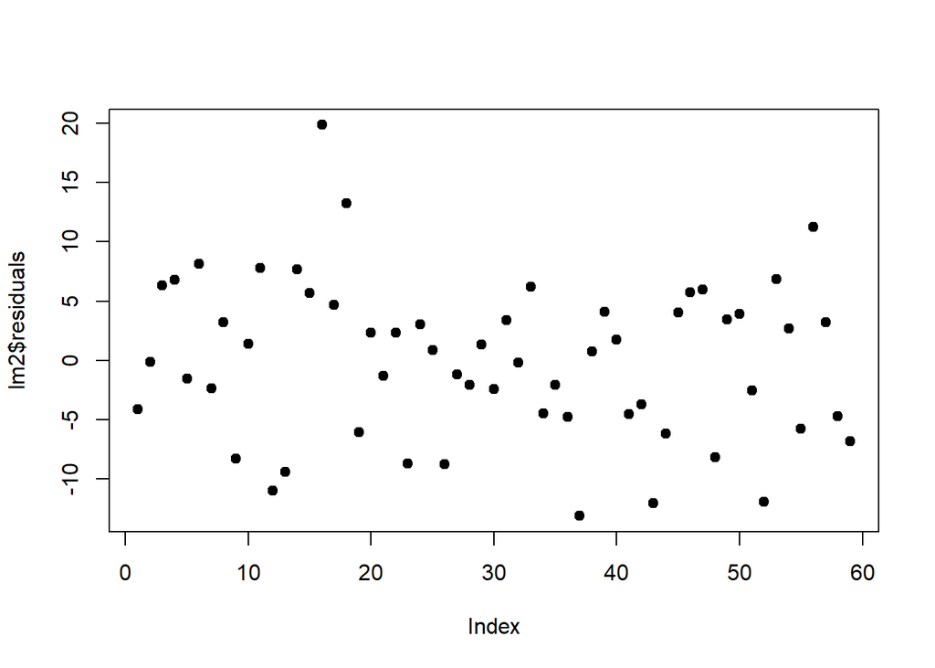

```r
plot(lm2$residuals, pch=19)
```

残差与数据的顺序不应该有关系。如果残差在某些特定的行号（例如按时间顺序、年龄顺序等）上聚集成团或呈现出某种趋势，这可能意味着模型漏掉了一些重要的预测因子：

- **残差图的期望**：残差图的目的是帮助我们检查模型是否合理。理想情况下，残差应该是随机分布的；也就是说，**残差不应依赖于输入数据的顺序**——如果模型已经很好地拟合了数据，那么我们不应该看到明显的模式或趋势。
- **行号的趋势或异常值**：如果在某些行号上，残差出现明显的趋势或聚集成团，这通常是因为模型未能捕捉到某些变量的影响。比如，数据可能是按时间顺序排列的，而模型可能忽略了时间因素的影响。这时，残差在时间序列上的聚集可能是未考虑到时间变量的信号，表明模型需要改进。
- **为什么不应该与顺序相关**：残差应该是“白噪声”——没有规律可言，代表模型已经捕捉到了数据中的所有系统性信息。如果残差的分布有明显的模式，那么它说明数据中的某些重要信息没有被模型捕捉到，可能是由于某些变量没有被纳入模型，或者是模型未能正确拟合这些变量的关系。